# Estadística Social: Probabilidades

Daniel Quinteros (@dquinterosr)

Última actualización: 13/10/2020

## 1. Concepto de probabilidades

### ¿Para qué sirven las probabilidades?

- 1. Suponga que hay doce preguntas de opción múltiple en un examen de estadística. Cada pregunta tiene cinco posibles respuestas, y sólo una de ellas es correcta. Encuentre la probabilidad de tener cuatro o menos respuestas correctas si un estudiante intenta responder a cada pregunta al azar. Podemos encontrar la probabilidad de tener exactamente 4 respuestas correctas por intentos aleatorios, utilizando la función ‘dbinom(correctas,intentos,probabilidad)’ de la siguiente manera.

```r
p = 1/5
n = 12
k = 4
dbinom(k,size=n,prob=0.2)
```

```
## [1] 0.1328756
```

```r
## Ejemplo tomado desde http://idaejin.github.io/courses/R/2019/euskaltel/distribuciones-de-probabilidad-en-r.html
```

```r
dbinom(1,12,0.2)
```

```
## [1] 0.2061584
```

- 3. Si con 7 o más respuestas *incorrectas* se reprueba el examen ¿Cuál sería la probabilidad de reprobar?

```r
#12 - 7 = 5 correctas o menos

dbinom(5,12,0.2) #P(5 correctas)
```

```
## [1] 0.05315022
```

```r
1-dbinom(5,12,0.2) #1-P = Q
```

```
## [1] 0.9468498
```

> En base a las probabilidades ¿se presentaría al próximo examen de estadística **sin estudiar?** Al menos, desde el punto de vista estadístico, no parece ser la mejor opción.

## 2. Reglas de probabilidad

### 2.1 Regla Nº1: Rango

Las probabilidades **siempre varían entre 0 y 1**

### 2.2 Regla Nº2: Eventos alternativos

La probabilidad de eventos alternativos es **igual a la suma de las probabilidades de los eventos individuales**

*P + (1 - P) = 1 | Q = 1 – P*

### 2.3 Regla Nº3: Ocurrencias conjuntas

La probabilidad de un evento con **doble éxito es una ocurrencia conjunta**

*P(a) + P(b) – P(a-b)*

### 2.4 Regla Nº4: Eventos compuestos

La probabilidad de un evento compuesto **es igual multiplicación de probabilidades individuales**

*P(a luego a) = P(a) x P(b)*

### 2.5 Regla Nº5: Reemplazo

En caso de eventos compuestos **especificar si es con o sin reemplazo**

## 3. Distribución de probabilidades

Recuerda que en una distribución normal:

> “a) La proporción de casos entre dos puntuaciones; b) El área bajo la curva entre estas dos puntuaciones; y c) La probabilidad de seleccionar al azar un caso entre estas puntuaciones; **SON TODAS IGUALES**” (Ferris, 2008)

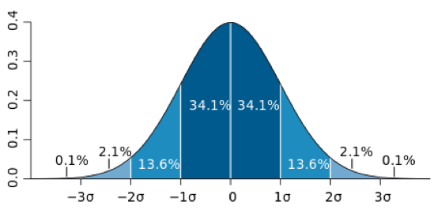

### 3.1 Teorema central del límite

```r
set.seed(8)
q1a <- rnorm(100, mean=91477, sd=15000)
q1b <- rnorm(1000, mean=91477, sd=15000)
q1c <- rnorm(10000, mean=91477, sd=15000)
q1d <- rnorm(1000000, mean=91477, sd=15000)

mean(q1a)
```

```
## [1] 90077.32
```

```r
mean(q1b)
```

```
## [1] 91233.63
```

```r
mean(q1c)
```

```
## [1] 91631.05
```

```r
mean(q1d)
```

```
## [1] 91462.43
```

```r
mean(q1a) - 91477
```

```
## [1] -1399.682
```

```r
mean(q1b) - 91477
```

```
## [1] -243.3736
```

```r
mean(q1c) - 91477
```

```
## [1] 154.0464
```

```r
mean(q1d) - 91477
```

```
## [1] -14.56574
```

```r
sd(q1a)
```

```
## [1] 16179.11
```

```r
sd(q1b)
```

```
## [1] 15252.42
```

```r
sd(q1c)
```

```
## [1] 15182.33
```

```r
sd(q1d)
```

```
## [1] 14995.38
```

```r
sd(q1a) - 15000
```

```
## [1] 1179.11
```

```r
sd(q1b) - 15000
```

```
## [1] 252.4179
```

```r
sd(q1c) - 15000
```

```
## [1] 182.3299
```

```r
sd(q1d) - 15000
```

```
## [1] -4.622212
```

### 3.2 Cálculo de probabilidades en R

Imagine que la media de las calificaciones en el curso de Estadística Social Inferencial durante los últimos años es igual a 5,1 con una desviación estándar de 0,9. Posiblemente a usted le interesa saber cuál es la probabilidad de pasar de curso, para lo cual vamos a calcular la probabilidad de que cualquier estudiante pueda aprobar con nota igual o superior a 3,95.

```r
pnorm(3.95, 5.1, 0.9, lower.tail = TRUE)
```

```
## [1] 0.1006639
```

Como la sintaxis contiene el argumento “lower.tail=TRUE”, nos está mostrando las probabilidades por debajo de ese valor o, mejor dicho, el área bajo la curva a la izquierda de la nota 3.95. Es decir, el valor 0.1006639 en realidad nos está diciendo que la probabilidad de reprobar el curso es igual a 10.07%.

Pero como somos personas positivas y lo que nos interesa es saber es la probabilidad de aprobar (¡y no de reprobar!), nos interesa conocer el área bajo la curva hacia la derecha de la distribución.

```r
pnorm(3.95, 5.1, 0.9, lower.tail = FALSE)
```

```
## [1] 0.8993361
```

Asimismo, podríamos intentar averiguar que calificación necesito para estar, por ejemplo, en el 15% superior del curso (para optar a becas, por ejemplo)

```r
qnorm(0.85, 5.1, 0.9, lower.tail = TRUE)
```

```
## [1] 6.03279
```

Y ¿para no estar en el 20% más bajo?

```r
qnorm(0.80, 5.1, 0.9, lower.tail = FALSE)
```

```
## [1] 4.342541
```